[figure not shown]

# Mission 5: Bitcoin Time Series Forecasting

#### Author: Colin Tomb

## Introduction

**Bitcoin** is a decentralized digital currency that was invented in 2008 by an unknown person or group using the pseudonym Satoshi Nakamoto. It was released as open-source software in 2009, and it's the first cryptocurrency to gain widespread popularity and use.

## Forecasting

Time series forecasting is a technique that utilises historical and current data to predict future values over a period of time or a specific point in the future. It involves building models through historical analysis and using them to make observations and drive future strategic decision-making.

Time series forecasting is helpful for businesses because it can guide their strategy and help them understand future trends. It can also help businesses optimise their operations, such as supply chain management, production and inventory planning, finance and budgeting, marketing and sales, and customer behaviour.

By using time series forecasting, businesses can anticipate future demand, reduce costs, improve efficiency, and increase customer satisfaction. Here are some examples of time series forecasting in action within different businesses:

- **Retail:** Time series forecasting can help retailers predict customer demand for different products across seasons, regions, and segments, and adjust their inventory, procurement, and pricing accordingly. For example, to optimise its supply chain and replenishment processes.
- **Finance:** Time series forecasting can help financial institutions and investors predict the closing price of a stock, the exchange rate of a currency, the interest rate of a bond, or the volatility of a market. For example, to provide insights and recommendations to its clients.
- **Healthcare:** Time series forecasting can help healthcare providers and researchers forecast the spread of a pandemic, the diagnosis of a disease, the medication planning for a patient, or the availability of hospital resources. For example, to monitor and project COVID-19 cases and deaths.
- **Manufacturing:** Time series forecasting can help manufacturers predict the demand for their products, the quality of their production, the maintenance of their equipment, or the occurrence of anomalies and failures. For example, to optimise wind turbine performance and maintenance.
- **Cybersecurity:** Time series forecasting can help cybersecurity professionals detect and prevent fraud, malware, phishing, denial-of-service attacks, or data breaches by analysing the patterns and trends of network traffic, user behavior, or system logs. For example, to identify and block fraudulent transactions.
> - Import Necessary Libraries click here
> - Section 1: Data Import and Basic Analysis click here
> - Section 2: Exploratory Data Analysis (EDA) click here
> - Section 3: Identify the trend click here
> - Section 4: Remove trend and identify seasonality click here
> - Section 5: Automatic time series de-composition click here
> - Section 6: Build the model click here
> - Summary click here

### Import Necessary Libraries

#### Back to Table of Contents

```python
# data manipulation and analysis python packages
import pandas as pd
import numpy as np

# plotting packages
import matplotlib.pyplot as plt
import seaborn as sns

# modelling and evaluation
from statsmodels.tsa.seasonal import seasonal_decompose
from statsmodels.tsa.stattools import adfuller
from statsmodels.graphics.tsaplots import plot_acf, plot_pacf
from statsmodels.tsa.holtwinters import ExponentialSmoothing
from statsmodels.tsa.arima.model import ARIMA
from statsmodels.tsa.statespace.sarimax import SARIMAX
import statsmodels.api as sm
from statsmodels.tsa.exponential_smoothing.ets import ETSModel
from sklearn.model_selection import train_test_split
from skimpy import skim
import warnings
warnings.filterwarnings('ignore')
```

## Section 1: Data Import and Basic Analysis

#### Back to Table of Contents

We'll start by loading the Bitcoin dataset into a DataFrame and displaying the first few rows to get a glimpse of the data structure.

This code reads a CSV file named *BTC-GBP.csv* into a `pandas` DataFrame called `btc_data`. The `index_col` parameter is set to `'Date'` column as the index of the DataFrame, replacing the default numeric index. This establishes a time series structure, facilitating subsequent time-based analyses and visualisations.

The `parse_dates` parameter is set to the `'Date'` column, which means that pandas will attempt to automatically parse the dates in the `'Date'` column as datetime objects. This conversion to datetime format allows for proper time series analysis, recognising the dates as chronological data points.

**Dataset used in this project was sourced from Yahoo Finance, as it provided the most granular view of the required data**

The dataset captures the daily closing prices of Bitcoin in GBP from September 24, 2017, to August 2, 2023. Bitcoin, a decentralised digital currency, often sees fluctuations in its price due to various market, economic, and geopolitical factors. This dataset provides a glimpse into Bitcoin's price dynamics over a span of almost six years.

- Date: Represents the specific day for the recorded price. It ranges from September 24, 2017, to August 2, 2023.
- Close: The closing price of Bitcoin for that specific date. This is the primary attribute we focus on for our time series analysis and forecasting.

```python
file_path = "https://raw.githubusercontent.com/ColinT2023/BPP_Data_Analytics/main/BTC-GBP.csv"
btc_data = pd.read_csv(file_path, index_col='Date', parse_dates=['Date'])
btc_data.head()
```

| Date | Open | High | Low | Close | Adj Close | Volume |
| --- | --- | --- | --- | --- | --- | --- |
| 2017-09-24 | 2813.838867 | 2813.838867 | 2718.034180 | 2727.625488 | 2727.625488 | 568815713 |
| 2017-09-25 | 2726.692383 | 2940.924561 | 2725.683105 | 2913.595703 | 2913.595703 | 1019821928 |
| 2017-09-26 | 2915.332031 | 2956.646973 | 2872.550293 | 2896.093750 | 2896.093750 | 776592286 |
| 2017-09-27 | 2896.532715 | 3143.000977 | 2889.631104 | 3135.764404 | 3135.764404 | 1259241565 |
| 2017-09-28 | 3133.121826 | 3202.117676 | 3057.130371 | 3108.742188 | 3108.742188 | 1275091220 |

```python
# Ascertaining data types
btc_data.info(memory_usage="deep")
```

```
<class 'pandas.core.frame.DataFrame'>
DatetimeIndex: 2139 entries, 2017-09-24 to 2023-08-02
Data columns (total 6 columns):
 #   Column     Non-Null Count  Dtype
---  ------     --------------  -----
 0   Open       2139 non-null   float64
 1   High       2139 non-null   float64
 2   Low        2139 non-null   float64
 3   Close      2139 non-null   float64
 4   Adj Close  2139 non-null   float64
 5   Volume     2139 non-null   int64
dtypes: float64(5), int64(1)
memory usage: 117.0 KB
```

```python
# Summary statistics for the closing price
closing_price_summary = btc_data['Close'].describe()
closing_price_summary
```

```
count     2139.000000
mean     15567.669847
std      11769.569966
min       2571.105469
25%       6004.727051
50%       9431.788086
75%      23464.016601
max      49813.441406
Name: Close, dtype: float64
```

```python
# richer alternative to .describe(). data shape, column dtypes, summary stats, distribution, missing stats
skim(btc_data)
```

```
╭──────────────────────────────────────────────── skimpy summary ─────────────────────────────────────────────────╮
│          Data Summary                Data Types                                                                 │
│ ┏━━━━━━━━━━━━━━━━━━━┳━━━━━━━━┓ ┏━━━━━━━━━━━━━┳━━━━━━━┓                                                          │
│ ┃ dataframe         ┃ Values ┃ ┃ Column Type ┃ Count ┃                                                          │
│ ┡━━━━━━━━━━━━━━━━━━━╇━━━━━━━━┩ ┡━━━━━━━━━━━━━╇━━━━━━━┩                                                          │
│ │ Number of rows    │ 2139   │ │ float64     │ 5     │                                                          │
│ │ Number of columns │ 6      │ │ int32       │ 1     │                                                          │
│ └───────────────────┴────────┘ └─────────────┴───────┘                                                          │
│                                                     number                                                      │
│ ┏━━━━━━━━━━━━┳━━━━┳━━━━━━┳━━━━━━━━━━━┳━━━━━━━━━━━━┳━━━━━━━━━━━━┳━━━━━━━━━━━┳━━━━━━━━━━━━┳━━━━━━━━━━━┳━━━━━━━━┓  │
│ ┃ column_nam ┃    ┃      ┃           ┃            ┃            ┃           ┃            ┃           ┃        ┃  │
│ ┃ e          ┃ NA ┃ NA % ┃ mean      ┃ sd         ┃ p0         ┃ p25       ┃ p75        ┃ p100      ┃ hist   ┃  │
│ ┡━━━━━━━━━━━━╇━━━━╇━━━━━━╇━━━━━━━━━━━╇━━━━━━━━━━━━╇━━━━━━━━━━━━╇━━━━━━━━━━━╇━━━━━━━━━━━━╇━━━━━━━━━━━╇━━━━━━━━┩  │
│ │ Open       │  0 │    0 │     16000 │      12000 │       2600 │      6000 │      23000 │     50000 │ █▂▂▁▁▁ │  │
│ │ High       │  0 │    0 │     16000 │      12000 │       2600 │      6200 │      24000 │     51000 │ █▂▂▂▁▁ │  │
│ │ Low        │  0 │    0 │     15000 │      11000 │       2500 │      5800 │      23000 │     49000 │ █▂▃▁▁  │  │
│ │ Close      │  0 │    0 │     16000 │      12000 │       2600 │      6000 │      23000 │     50000 │ █▂▂▁▁▁ │  │
│ │ Adj Close  │  0 │    0 │     16000 │      12000 │       2600 │      6000 │      23000 │     50000 │ █▂▂▁▁▁ │  │
│ │ Volume     │  0 │    0 │ -41000000 │ 1200000000 │ -210000000 │ -11000000 │ 1000000000 │ 210000000 │ ▇██▇▇▇ │  │
│ │            │    │      │           │            │          0 │        00 │            │         0 │        │  │
│ └────────────┴────┴──────┴───────────┴────────────┴────────────┴───────────┴────────────┴───────────┴────────┘  │
╰────────────────────────────────────────────────────── End ──────────────────────────────────────────────────────╯
```

```python
# Check for NaN values across all columns
btc_data.isna().any()
```

```
Open         False
High         False
Low          False
Close        False
Adj Close    False
Volume       False
dtype: bool
```

## Section 2: Exploratory Data Analysis

#### Back to Table of Contents

In this section we will visualise the data, to establish patterns and trends, that will aid in uncovering insights

> This chart shows the entire history of Bitcoin's closing price in British Pounds (GBP). It's like a snapshot of Bitcoin's journey over time. When looking at this plot, you can see how the price has moved up and down. It helps you grasp the overall picture of how Bitcoin's value has changed, including periods of rapid growth or decline.

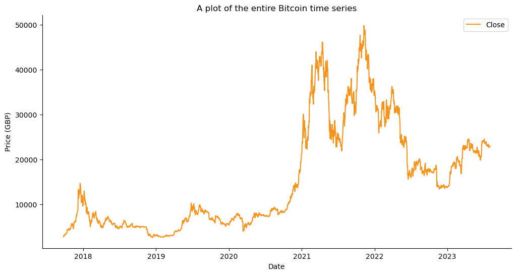

```python
# Plotting the entire time series with the specified color and style
plt.figure(figsize=(12, 6))
plt.plot(btc_data['Close'], color='#f7931a', label='Close')
plt.title('A plot of the entire Bitcoin time series')
plt.xlabel('Date')
plt.ylabel('Price (GBP)')
plt.legend()
plt.gca().spines['top'].set_visible(False)
plt.gca().spines['right'].set_visible(False)
plt.grid(False)
plt.show()
```

#### Middle Plot: Zoomed Inset - 2018 Peak

> - This zoomed-in view focuses on a specific moment in late 2017 to early 2018 when Bitcoin's price reached a significant peak.

#### Bottom Plot: Zoomed Inset - 2021 Peak

> - Here, we're zooming in on another important period, from late 2020 to early 2021. This was another time when Bitcoin's price soared to new heights. By looking closely at this period, you can see the fluctuations and dynamics that led to this peak.

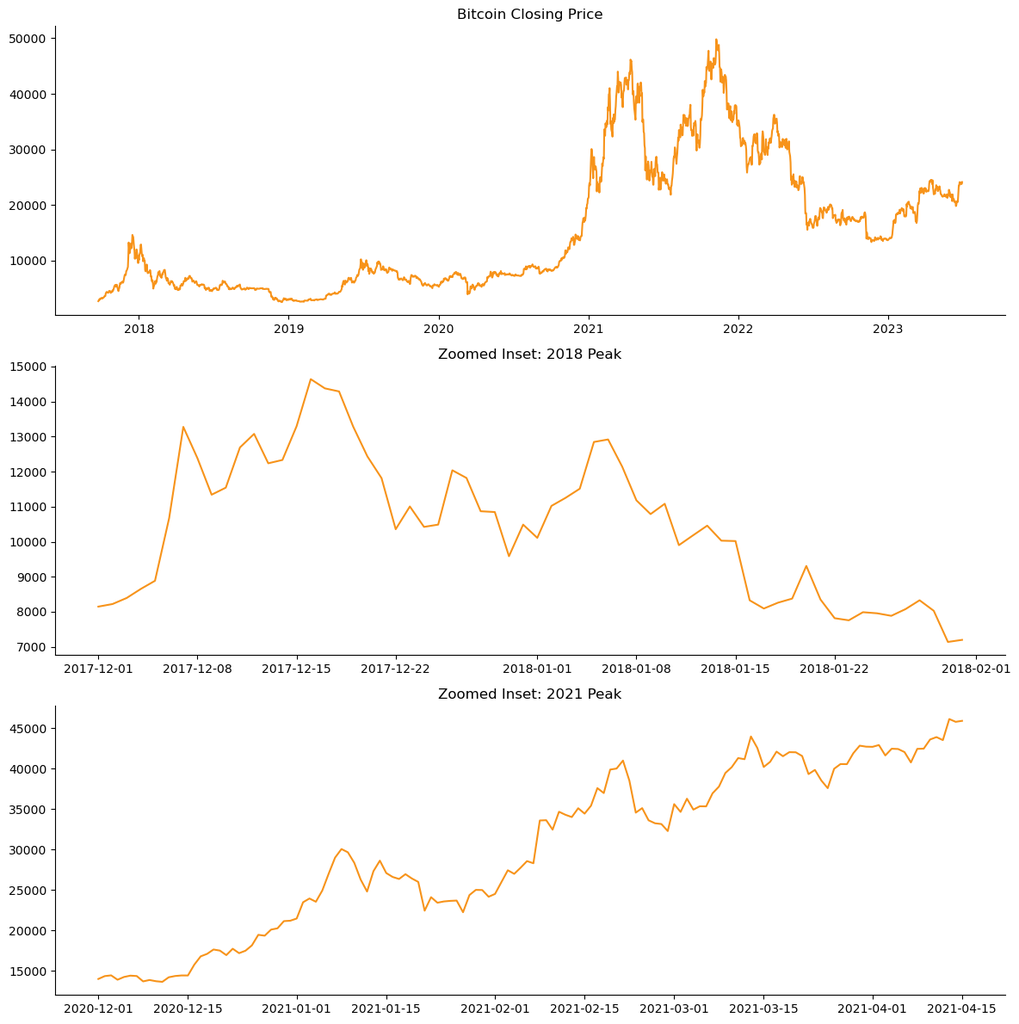

```python
# Function to create a zoomed-in subplot for a specific time period (avoiding line drop below x-axis)
def create_zoom_subplot(ax, start_date, end_date, title, color):
    ax.plot(btc_data['Close'][start_date:end_date], color=color)
    ax.set_title(title)
    ax.spines['top'].set_visible(False)
    ax.spines['right'].set_visible(False)
    ax.grid(False)

# Plotting the entire time series with separate subplots for the peaks in 2018 and 2021
fig, axs = plt.subplots(3, 1, figsize=(12, 12), sharex=False)

# Main Plot
create_zoom_subplot(axs[0], start_date='2013-01-01', end_date='2023-06-30', title='Bitcoin Closing Price', color='#f7931a')

# 2018 Peak
create_zoom_subplot(axs[1], start_date='2017-12-01', end_date='2018-01-31', title='Zoomed Inset: 2018 Peak', color='#f7931a')

# 2021 Peak
create_zoom_subplot(axs[2], start_date='2020-12-01', end_date='2021-04-15', title='Zoomed Inset: 2021 Peak', color='#f7931a')

plt.tight_layout()
plt.show()
```

Descriptive Statistics:

- Count: There are a total of 2139 data points (days) in the dataset.
- Mean: The average closing price of Bitcoin during this period is approximately £15,567.67.
- Std: The standard deviation, which measures the amount of variation or dispersion of a set of values, is approximately £11,769.57.
- Min & Max: The minimum closing price observed was £2,571.11, and the maximum was £49,813.44. Percentiles: The 25th, 50th (median), and 75th percentiles give us an idea about the distribution of the data. For instance, 25% of the data points have a value less than £6,004.73, and 75% of the data points are less than £23,464.02.

[output not shown]

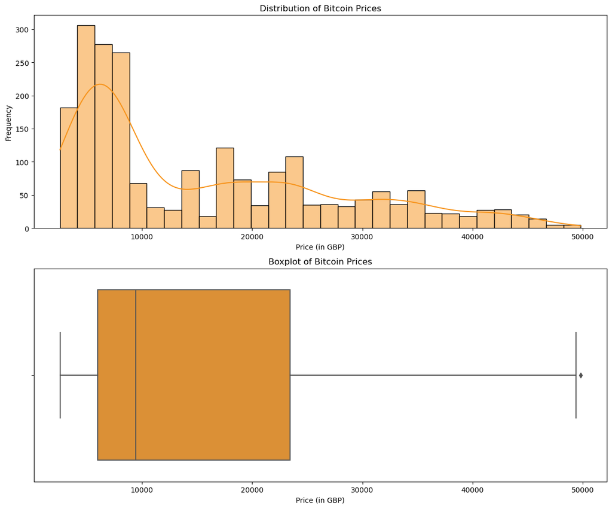

```python
# Adjusting the color theme of the distribution plot and the boxplot to #f7931a
fig, ax = plt.subplots(2, 1, figsize=(12, 10))

# Distribution plot
sns.histplot(btc_data['Close'], kde=True, ax=ax[0], color='#f7931a', bins=30)
ax[0].set_title('Distribution of Bitcoin Prices')
ax[0].set_xlabel('Price (in GBP)')
ax[0].set_ylabel('Frequency')

# Boxplot
sns.boxplot(x=btc_data['Close'], color='#f7931a', ax=ax[1])
ax[1].set_title('Boxplot of Bitcoin Prices')
ax[1].set_xlabel('Price (in GBP)')

plt.tight_layout()
plt.show()
```

- Distribution of Bitcoin Prices: The histogram displays the frequency distribution of Bitcoin prices. The smooth line, known as the kernel density estimation (KDE), gives a smoothed version of the histogram and is used to visualize the probability distribution of the data.
- Boxplot of Bitcoin Prices: The boxplot provides a visual summary of the main characteristics of the distribution of Bitcoin prices. The central box represents the interquartile range, the line inside the box is the median, and the "whiskers" show the range of the data. Any data points outside the whiskers can be considered as outliers.

### Bitcoin Halving and Its Impacts on Price

Bitcoin operates on a decentralised ledger system known as the blockchain. One of its most unique features is the concept of "halving." Every 210,000 blocks — approximately every four years — the reward given to Bitcoin miners for processing transactions is cut in half. This phenomenon is known as a "halving."

Why does this matter? The halving reduces the number of new bitcoins entering circulation. This scarcity mechanism is built into the Bitcoin protocol by its creator, Satoshi Nakamoto, as a deflationary measure. The logic is simple: as the reward for miners decreases, the supply of new bitcoins entering the market diminishes, and if demand remains constant or increases, the price should theoretically rise.

Historically, in the cycles following the halvings, Bitcoin's price has seen significant upticks, especially around 12-18 months post-halving. While correlation doesn't imply causation, many analysts and enthusiasts believe the halving events play a pivotal role in driving Bitcoin's price upwards.

In our current dataset, we can observe the effects of the 3rd halving, which took place on 11th May 2020. As the chart demonstrates, there's a marked increase in Bitcoin's price in the year following this halving. Unfortunately, due to the constraints of our dataset, we cannot go back to analyse this pattern in the earlier halvings, but historical accounts and data from other sources have indicated similar price behaviors post previous halving events.

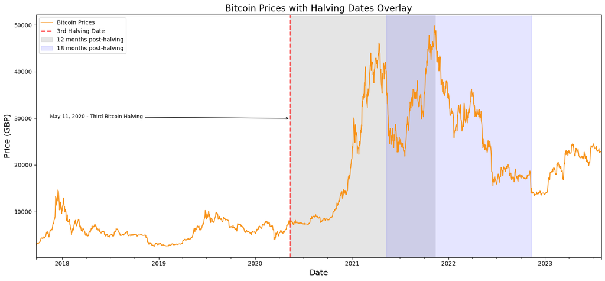

```python
# Plotting the Bitcoin prices with the updated annotation position
fig, ax = plt.subplots(figsize=(15,7))

# Plotting the daily closing prices
btc_data['Close'].plot(ax=ax, color='#f7931a', label='Bitcoin Prices')
ax.axvline(pd.Timestamp('2020-05-11'), color='r', linestyle='--', lw=2, label='3rd Halving Date')

# Highlighting the 12-18 months post-halving
ax.axvspan(pd.Timestamp('2020-05-11'), pd.Timestamp('2021-11-11'), color='grey', alpha=0.2, label='12 months post-halving')
ax.axvspan(pd.Timestamp('2021-05-11'), pd.Timestamp('2022-11-11'), color='blue', alpha=0.1, label='18 months post-halving')

# Adding an annotation for the third Bitcoin halving at a higher position on the y-axis
ax.annotate('May 11, 2020 - Third Bitcoin Halving',
            xy=(pd.Timestamp('2020-05-11'), 30000),
            xytext=(pd.Timestamp('2018-05-11'), 30000),
            arrowprops=dict(facecolor='black', arrowstyle='->'),
            fontsize=9,
            ha='center')

# Setting the title and labels
ax.set_title('Bitcoin Prices with Halving Dates Overlay', fontsize=16)
ax.set_xlabel('Date', fontsize=14)
ax.set_ylabel('Price (GBP)', fontsize=14)
ax.legend()
plt.tight_layout()
plt.show()
```

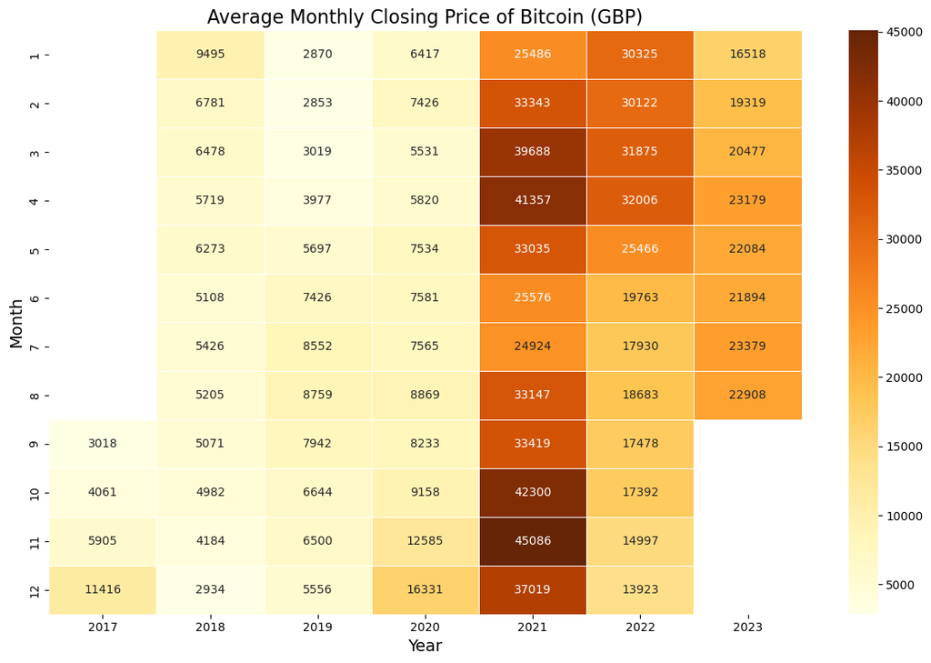

```python
# Extracting month and year from the Date
btc_data['Year'] = btc_data.index.year
btc_data['Month'] = btc_data.index.month

# Creating a pivot table for average closing price by month and year
monthly_pivot = btc_data.pivot_table(values='Close', index='Month', columns='Year', aggfunc='mean')

# Plotting the heatmap
plt.figure(figsize=(12, 8))
sns.heatmap(monthly_pivot, cmap='YlOrBr', annot=True, fmt=".0f", linewidths=.5)
plt.title('Average Monthly Closing Price of Bitcoin (GBP)', fontsize=16)
plt.xlabel('Year', fontsize=14)
plt.ylabel('Month', fontsize=14)
plt.tight_layout()
plt.show()
```

- Year-End Market Dynamics: Some investors might be realigning their portfolios towards the end of the year. There might also be an influx of year-end bonuses that some choose to invest in Bitcoin.
- Increased Trading Activity: The last quarter can often see increased trading activity due to various global financial timelines, holidays, and shopping events.
- Historical Events: Specific events in the Bitcoin and broader cryptocurrency ecosystem (like regulatory news, technological advancements, or macroeconomic factors) could have triggered price surges in the last quarters of specific years.

Actual Bitcoin Quarterly performance over the years.

[figure not shown]

## Section 3: Identify the trend

#### Back to Table of Contents

```python
# Calculating moving averages with different window sizes (in months) to identify trends
btc_data['4-MA'] = btc_data['Close'].rolling(window=4, center=True).mean()
btc_data['6-MA'] = btc_data['Close'].rolling(window=6, center=True).mean()
btc_data['12-MA'] = btc_data['Close'].rolling(window=12, center=True).mean()

# Displaying the first 8 rows of the Bitcoin dataset with the calculated moving averages
btc_data_with_ma = btc_data[['Close', '4-MA', '6-MA', '12-MA']].head(8)
btc_data_with_ma
```

| Date | Close | 4-MA | 6-MA | 12-MA |
| --- | --- | --- | --- | --- |
| 2017-09-24 | 2727.625488 | NaN | NaN | NaN |
| 2017-09-25 | 2913.595703 | NaN | NaN | NaN |
| 2017-09-26 | 2896.093750 | 2918.269836 | NaN | NaN |
| 2017-09-27 | 3135.764404 | 3013.549011 | 2981.586304 | NaN |
| 2017-09-28 | 3108.742188 | 3062.074158 | 3066.783732 | NaN |
| 2017-09-29 | 3107.696289 | 3147.753235 | 3129.240519 | NaN |
| 2017-09-30 | 3238.810059 | 3185.896241 | 3200.228556 | 3124.732483 |
| 2017-10-01 | 3288.336426 | 3239.216187 | 3221.008505 | 3176.259237 |

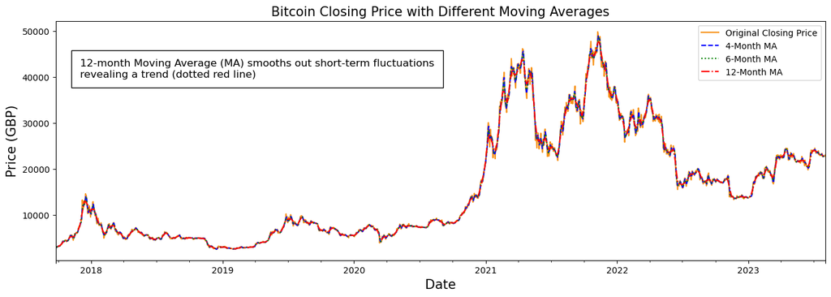

```python
# Plotting the original closing price along with the calculated moving averages
btc_data[['Close', '4-MA', '6-MA', '12-MA']].plot(style=['-', '--', ':', '-.'], figsize=(16, 5), color=['#f7931a', 'blue', 'green', 'red'])


# Adding explanatory text
plt.text('2017-12-01', 40000, """12-month Moving Average (MA) smooths out short-term fluctuations
revealing a trend (dotted red line)""", fontsize=12, bbox=dict(facecolor='white', edgecolor='black', pad=10))


plt.xlabel('Date', fontsize=15)
plt.ylabel('Price (GBP)', fontsize=15)
plt.title('Bitcoin Closing Price with Different Moving Averages', fontsize=15)
plt.legend(['Original Closing Price', '4-Month MA', '6-Month MA', '12-Month MA'])
plt.grid(False)
plt.show()
```

This chart is a visual representation of time series decomposition and trend analysis, common techniques in time series forecasting. It allows for understanding the different components of the data and how they interact, which can be essential in building accurate predictive models.

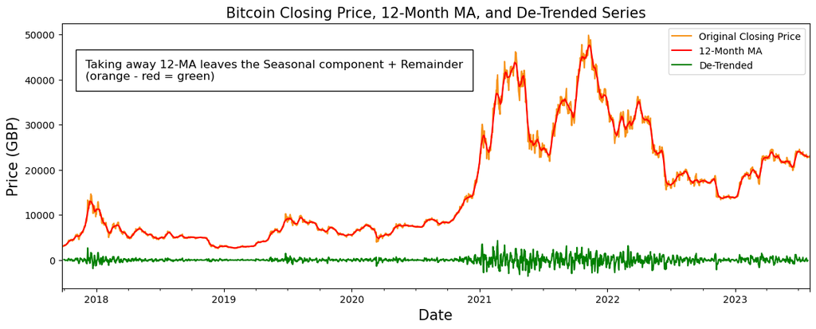

```python
# Calculating the de-trended series
btc_data['de-trended'] = btc_data['Close'] - btc_data['12-MA']

# Plotting the original closing price, 12-month moving average, and de-trended series
btc_data[['Close', '12-MA', 'de-trended']].plot(figsize=(14, 5), color=['#f7931a', 'red', 'green'])


# Adding explanatory text
plt.text('2017-12-01', 40000, """Taking away 12-MA leaves the Seasonal component + Remainder
(orange - red = green)""", fontsize=12, bbox=dict(facecolor='white', edgecolor='black', pad=10))
plt.xlabel('Date', fontsize=15)
plt.ylabel('Price (GBP)', fontsize=15)
plt.title('Bitcoin Closing Price, 12-Month MA, and De-Trended Series', fontsize=15)
plt.legend(['Original Closing Price', '12-Month MA', 'De-Trended'])
plt.grid(False)

plt.show()
```

# Section 4: Remove trend and identify seasonality

#### Back to Table of Contents

This plot helps us dissect Bitcoin's price into different layers, allowing us to see not only how it changes over time but also how certain patterns repeat every year. By understanding these repeating patterns, we can make more informed predictions about future price movements. It's like uncovering the rhythm of the data, which can guide us in anticipating what might come next.

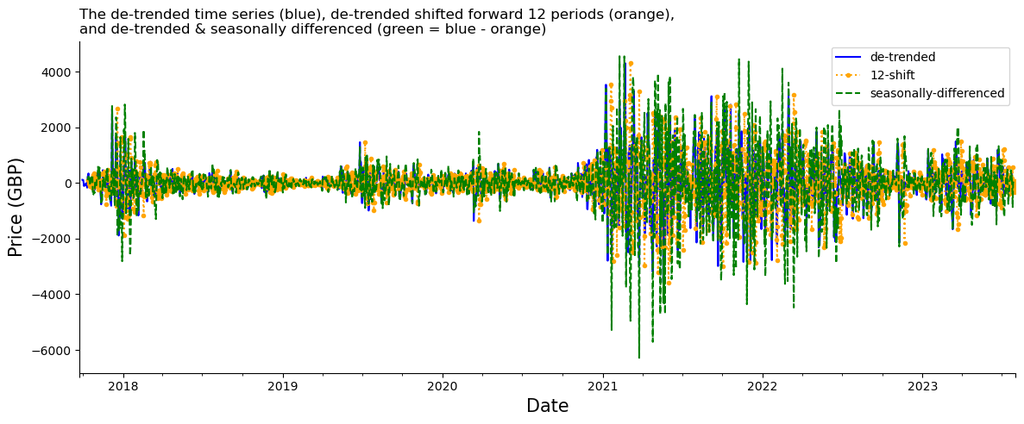

```python
# Shifting the de-trended data forward by 12 periods (months)
btc_data['12-shift'] = btc_data['de-trended'].shift(periods=12)

# Calculating the seasonally differenced data
btc_data['seasonally-differenced'] = btc_data['de-trended'] - btc_data['12-shift']

# Plotting the de-trended data, the shifted data, and the seasonally differenced data
ax = btc_data[['de-trended', '12-shift', 'seasonally-differenced']].plot(style=['-', ':.', '--'], figsize=(14, 5), color=['blue', 'orange', 'green'])

# Removing the top and right spines for a cleaner look
for spine in ['top', 'right']:
    ax.spines[spine].set_visible(False)

plt.title("""The de-trended time series (blue), de-trended shifted forward 12 periods (orange),
and de-trended & seasonally differenced (green = blue - orange)""", fontsize=12, loc='left')
plt.xlabel('Date', fontsize=15)
plt.ylabel('Price (GBP)', fontsize=15)
plt.grid(False)

plt.show()
```

The lack of patterns in longer lags emphasises the complexity and unpredictability of Bitcoin's price in the longer term, making it a challenging subject for precise forecasting.

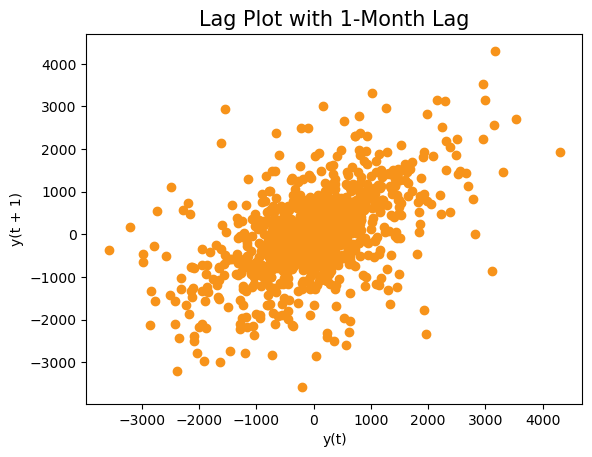

```python
pd.plotting.lag_plot(btc_data['de-trended'], lag=1, c='#f7931a')
plt.title('Lag Plot with 1-Month Lag', fontsize=15)
plt.grid(False)
plt.show()
```

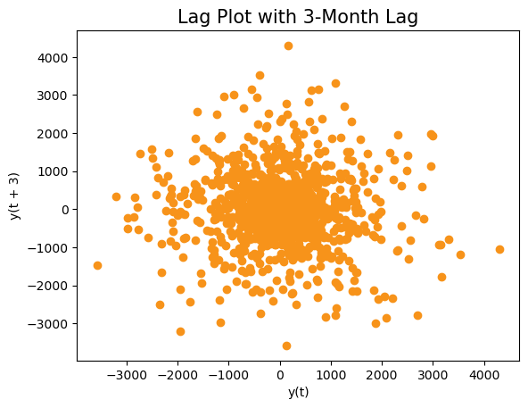

```python
pd.plotting.lag_plot(btc_data['de-trended'], lag=3, c='#f7931a')
plt.title('Lag Plot with 3-Month Lag', fontsize=15)
plt.grid(False)
plt.show()
```

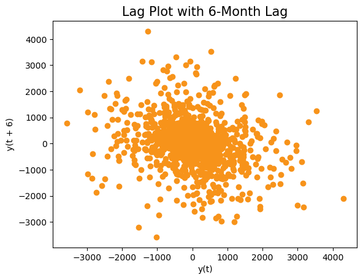

```python
pd.plotting.lag_plot(btc_data['de-trended'], lag=6, c='#f7931a')
plt.title('Lag Plot with 6-Month Lag', fontsize=15)
plt.grid(False)
plt.show()
```

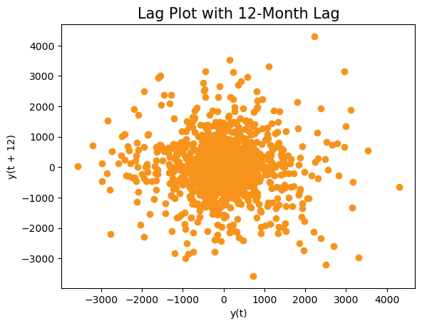

```python
pd.plotting.lag_plot(btc_data['de-trended'], lag=12, c='#f7931a')
plt.title('Lag Plot with 12-Month Lag', fontsize=15)
plt.grid(False)
plt.show()
```

```python
btc_data['de-trended'].corr(btc_data['12-shift']).round(2)
```

```
-0.02
```

```python
# Calculate and print the correlation coefficient between the de-trended series and its 1 to 15-lag values
for shift in range(1, 16):
    correlation = btc_data['de-trended'].corr(btc_data['de-trended'].shift(shift))
    print(f"{shift}-Month Lag: {correlation:.2f}")
```

```
1-Month Lag: 0.54
2-Month Lag: 0.20
3-Month Lag: -0.05
4-Month Lag: -0.22
5-Month Lag: -0.29
6-Month Lag: -0.25
7-Month Lag: -0.18
8-Month Lag: -0.08
9-Month Lag: 0.03
10-Month Lag: 0.05
11-Month Lag: 0.01
12-Month Lag: -0.02
13-Month Lag: -0.02
14-Month Lag: -0.04
15-Month Lag: -0.05
```

- X-Axis (Time series period shift forwards): This represents the number of periods (lags) we shift the data forward to compare it to itself. It ranges from 0 to 22, meaning we're looking at how the Bitcoin price correlates with itself shifted by up to 22 periods.
- Y-Axis (Correlation): This represents the correlation coefficient, which quantifies how strongly two sets of data are related. A value of 1 means a perfect positive correlation, -1 means a perfect negative correlation, and 0 means no correlation.
- Dots: Each dot represents the correlation between the de-trended Bitcoin price and itself shifted forward by the corresponding number of periods on the x-axis. For example, the dot at shift-1 tells us how today's price is related to yesterday's price, and so on.
- Blue Shading (95% Confidence Intervals): The blue area around the dots provides a range within which we expect 95% of the correlations to fall if there were no real relationship between the lags. If a dot falls outside this blue area, it indicates a significant correlation at that lag.

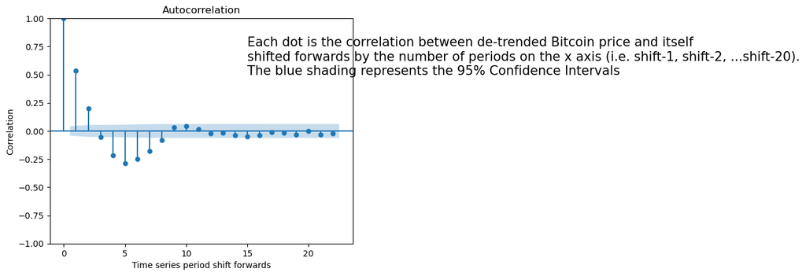

```python
import statsmodels.graphics.tsaplots as tsaplots

# Plotting the Auto-Correlation Function (ACF) for the de-trended Bitcoin price
tsaplots.plot_acf(btc_data['de-trended'], missing='drop', lags=22, alpha=0.05)

plt.xlabel('Time series period shift forwards')
plt.ylabel('Correlation')

plt.text(15, 0.5, """Each dot is the correlation between de-trended Bitcoin price and itself
shifted forwards by the number of periods on the x axis (i.e. shift-1, shift-2, ...shift-20).
The blue shading represents the 95% Confidence Intervals""", fontsize=15)
plt.show()
```

## Section 5: Automatic time series de-composition

#### Back to Table of Contents

- **Observed:** This plot shows the actual closing price of Bitcoin over time. It's the raw data, including all fluctuations, trends, and seasonal patterns.
- **Trend:** This plot reveals the underlying trend in the Bitcoin price. By smoothing out short-term fluctuations, it highlights the general upward or downward movement over time. In this case, we can see significant upward trends in certain periods, followed by stabilisation or declines.
- **Seasonal:** This plot represents the repetitive patterns that occur at regular intervals. While Bitcoin might not exhibit strong seasonality (e.g., higher prices in winter and lower in summer), some periodic patterns might still be present, such as weekly or monthly variations. However, the plot here doesn't show any clear seasonal pattern.
- **Residual:** This plot captures the remainder after extracting the trend and seasonal components. It's the noise and random variations that can't be attributed to any specific pattern or trend. A well-fitted model would ideally have residuals that look like random noise with no discernible pattern.

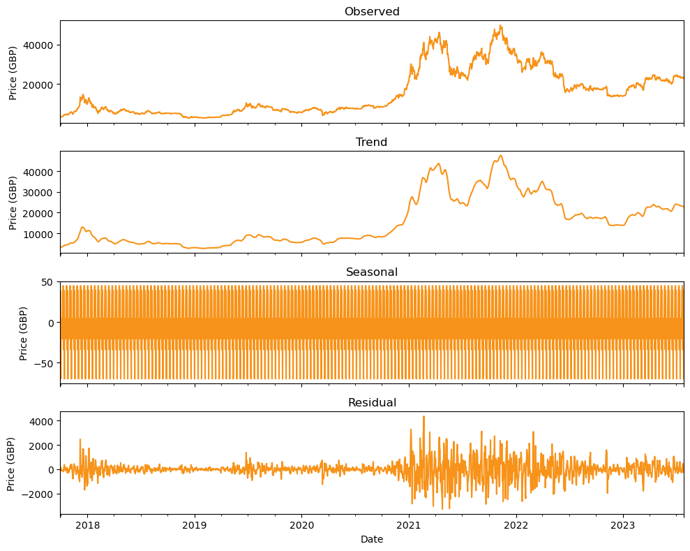

```python
# Applying seasonal decomposition to the Bitcoin closing price
decomp = seasonal_decompose(btc_data['Close'], model='additive', period=12)

# Extracting the components
trend = decomp.trend.dropna()
seasonal = decomp.seasonal.dropna()
residual = decomp.resid.dropna()
observed = decomp.observed.dropna()

# Plotting the components
fig, axes = plt.subplots(4, 1, figsize=(10, 8), sharex=True)

observed.plot(ax=axes[0], color='#f7931a')
axes[0].set_title('Observed')
axes[0].set_ylabel('Price (GBP)')

trend.plot(ax=axes[1], color='#f7931a')
axes[1].set_title('Trend')
axes[1].set_ylabel('Price (GBP)')

seasonal.plot(ax=axes[2], color='#f7931a')
axes[2].set_title('Seasonal')
axes[2].set_ylabel('Price (GBP)')

residual.plot(ax=axes[3], color='#f7931a')
axes[3].set_title('Residual')
axes[3].set_xlabel('Date')
axes[3].set_ylabel('Price (GBP)')

plt.tight_layout()
plt.show()
```

- Original Bitcoin Price (Orange Line): This line represents the actual closing price of Bitcoin over the given time period. It includes all the fluctuations, trends, and seasonal patterns.
- Trend Component (Blue Dashed Line): This line shows the underlying trend in the Bitcoin price, removing the noise and seasonal effects. It helps us see the overall upward or downward direction of the price.
- Reconstructed Price (Green Dotted Line): This line is formed by adding the trend, seasonal, and residual components together. It's a re-construction of the original price using the components obtained from seasonal decomposition.

The close alignment between the orange and green lines indicates that the seasonal decomposition has accurately captured the main components of the time series. The differences between these lines can be attributed to noise or random variations that are not captured by the trend and seasonal components.

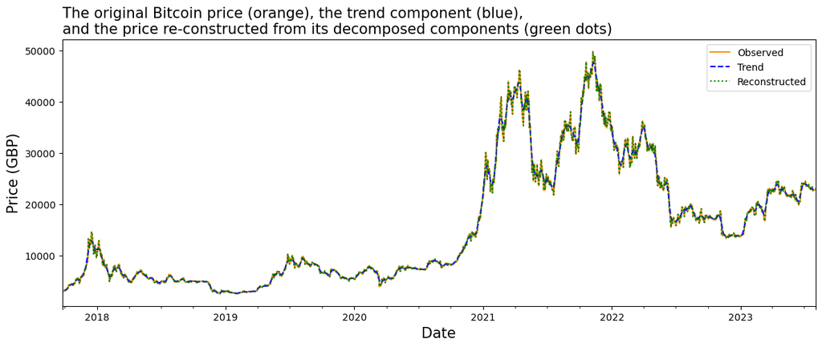

```python
# Creating a DataFrame that joins the observed, residual, trend, and seasonal components
btc_decomp_df = decomp.observed.to_frame().join(decomp.resid).join(decomp.trend).join(decomp.seasonal)
btc_decomp_df['check'] = btc_decomp_df['resid'] + btc_decomp_df['trend'] + btc_decomp_df['seasonal']
btc_decomp_df.columns = ['Observed', 'Residual', 'Trend', 'Seasonal', 'Reconstructed']

# Plotting the original time series, the trend component, and the reconstructed time series
btc_decomp_df[['Observed', 'Trend', 'Reconstructed']].plot(style=['-', '--', ':'], figsize=(14, 5), color=['#f7931a', 'blue', 'green'])

plt.title("""The original Bitcoin price (orange), the trend component (blue),
and the price re-constructed from its decomposed components (green dots)""", fontsize=15, loc='left')
plt.xlabel('Date', fontsize=15)
plt.ylabel('Price (GBP)', fontsize=15)
plt.grid(False)
plt.show()
```

As I delve into this analysis, it's essential to remember why I've conducted all this data exploration and decomposition. The primary goal is to guide the choice of a modeling approach to create more precise forecasts. From the exploratory data analysis (EDA) and time series decomposition of Bitcoin's price, I have observed the following:

**Trend:** Unlike a consistent upward or downward trend over time, the Bitcoin price exhibits complex and non-linear trends, reflecting its highly volatile nature.

**Seasonality:** While exploring different lag periods, I did not find a strong seasonal pattern within the Bitcoin data. This lack of seasonality is expected, as cryptocurrencies often react to market events and news rather than annual cycles.

The complexity of the trend and absence of clear seasonality in Bitcoin's price makes choosing the right model for forecasting a nuanced task. Traditional models like Error Trend & Seasonality (ETS) may not be the best fit, as they rely on the presence of stable trends and seasonal patterns.

By leveraging Python and exploring more advanced modeling techniques, I have the opportunity to build a tailored model that accommodates Bitcoin's unique characteristics. This approach allows for a more accurate and transparent forecast, reflecting the complex dynamics of the cryptocurrency market.

## Section 6: Build the model

#### Back to Table of Contents

### 1 Split the data into train and test

I want to know how well our model might forecast values for days outside of the data we have available, so to estimate how well it might forecast into the future.

I therefore split the data into training data (used to build the model) and test data (used to test how well the model works on data it has not seen before).

A common practice in time series forecasting (and machine learning, in general) is to allocate approximately 80% of the data for training and 20% for testing. This 80/20 split ensures that the model has a sufficient amount of data to learn the underlying patterns while also having a separate dataset to validate its forecasting accuracy.

- Training Data: The data from September 24, 2017, to May 31, 2022, encompasses nearly five years (80%). This portion is used to train our forecasting model.
- Testing Data: The data from June 1, 2022, onward serves as our testing set (remaining 20%). This portion allows us to evaluate how well our model performs in predicting future Bitcoin prices.

```python
train_data = btc_data.query('Date <= "2022-05-31"')
test_data = btc_data.query('Date >= "2022-06-01"')
```

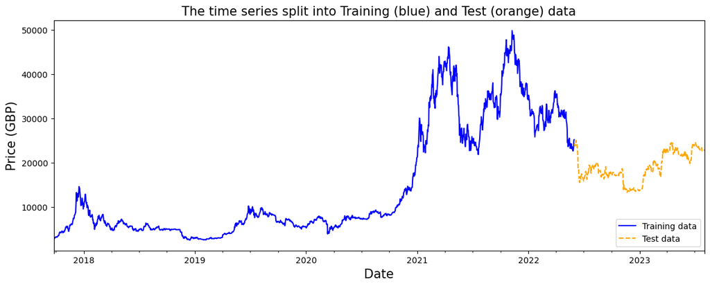

```python
# Plotting the training and testing data
ax = train_data['Close'].plot(color='blue', figsize=(14, 5))
test_data['Close'].plot(ax=ax, style='--', color='orange')

plt.legend(labels=['Training data', 'Test data'], loc=4)
plt.title("The time series split into Training (blue) and Test (orange) data", fontsize=15)
plt.xlabel('Date', fontsize=15)
plt.ylabel('Price (GBP)', fontsize=15)
plt.grid(False)
plt.show()
```

#### 2 Build a simple baseline model

I'll use the ETSModel() function to create the ETS model specifically for Bitcoin price analysis, and then use its .fit() method to tailor the model to our data. This process allows the model to understand the underlying patterns in Bitcoin's price history, preparing it to make future predictions.

```python
ets_model_simple = sm.tsa.ETSModel(train_data['Close'].astype('float64'),
                                   error='add',
                                   trend=None,
                                   seasonal=None).fit()

ets_model_simple.summary()
```

ETS Results

| Dep. Variable: | Close | No. Observations: | 1711 |
| --- | --- | --- | --- |
| Model: | ETS(ANN) | Log Likelihood | -13739.901 |
| Date: | Sun, 06 Aug 2023 | AIC | 27485.801 |
| Time: | 17:19:34 | BIC | 27502.136 |
| Sample: | 09-24-2017 | HQIC | 27491.847 |
|  | - 05-31-2022 | Scale | 552821.282 |
| Covariance Type: | approx |  |  |

|  | coef | std err | z | P>\|z\| | [0.025 | 0.975] |
| --- | --- | --- | --- | --- | --- | --- |
| smoothing_level | 0.9716 | 0.024 | 40.346 | 0.000 | 0.924 | 1.019 |
| initial_level | 2769.1245 | 743.233 | 3.726 | 0.000 | 1312.414 | 4225.835 |

| Ljung-Box (Q): | 0.01 | Jarque-Bera (JB): | 5687.00 |
| --- | --- | --- | --- |
| Prob(Q): | 1.00 | Prob(JB): | 0.00 |
| Heteroskedasticity (H): | 13.89 | Skew: | -0.12 |
| Prob(H) (two-sided): | 0.00 | Kurtosis: | 11.93 |

Warnings:  
[1] Covariance matrix calculated using numerical (complex-step) differentiation.

### 3 Interpret the model results

In summary, this model is a very simple representation of the Bitcoin price, basically saying that the best guess for tomorrow's price is today's price. While it may capture some of the overall behavior, it ignores any trends or seasonal patterns that might exist in the data. It's a starting point, but more complex models may provide better insights and predictions.

Let's compare the fitted model to the actual values to see clearly that our baseline model simply uses the previous value

| Date | Close | fitted_values |
| --- | --- | --- |
| 2017-09-24 | 2727.625488 | 2769.124513 |
| 2017-09-25 | 2913.595703 | 2728.804962 |
| 2017-09-26 | 2896.093750 | 2908.343630 |
| 2017-09-27 | 3135.764404 | 2896.441913 |
| 2017-09-28 | 3108.742188 | 3128.962444 |

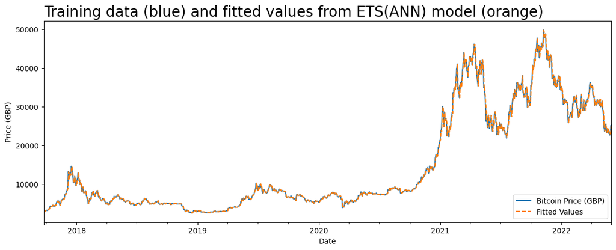

```python
# Adding the fitted values from the model to the training data
train_data['fitted_values'] = ets_model_simple.fittedvalues

# Plotting the training data and the fitted values
train_data[['Close', 'fitted_values']].plot(style=['-', '--'], figsize=(14, 5))

# Displaying the first few rows of the training data
display(train_data[['Close', 'fitted_values']].head())

# Adding a legend and title to the plot
plt.legend(labels=['Bitcoin Price (GBP)', 'Fitted Values'], loc=4)
plt.title('Training data (blue) and fitted values from ETS(ANN) model (orange)', fontsize=20, loc='left')
plt.xlabel('Date')
plt.ylabel('Price (GBP)')
plt.show()
```

- Model Simplicity: The ETS(ANN) model used here is quite simple. It's characterized by additive errors and does not account for trend or seasonality. Essentially, it's primarily focused on capturing the level of the data.
- Smoothing Level Close to 1: The smoothing level (or alpha) in the results was found to be very close to 1. This means that the model gives significant weight to the most recent observation when forecasting the next value. In other words, it's nearly equivalent to a naive forecast, where the last observation is simply repeated moving forward in time.
- High Sensitivity to Recent Observations: Because of the high smoothing level, the model is highly sensitive to recent observations. This allows it to closely track changes in the data, leading to a tight fit with the actual values.
- Training Data Fit: Keep in mind that this fit is on the training data, which is the data the model was trained on. A model can often fit the training data quite well, especially a model that is sensitive to recent changes. The real test of a model's quality is how well it performs on unseen data, which would be the test data in this case.
- Potential Overfitting: While a near-perfect fit might seem ideal, it can also be a sign of overfitting, especially with a simple model. Overfitting occurs when a model fits the noise or random fluctuations in the training data rather than the underlying pattern. This can lead to poor performance on new, unseen data.

### 4 Understanding exponential smoothing

In Simple Exponential Smoothing (SES) Model, the best next guess for each period is the weighted average of all the data that came before. But how is the weight applied?

Below we will see that as we change the smoothing level (alpha) gradually to be closer to 1, then additional weight is given to previous observations that decrease exponentially.

```python
alpha = 0.001 # Play around with this value with numbers increasingly closer to 1
N = 10 # Length of the DataFrame (you can adjust this)
btc_df = pd.DataFrame({'alpha value': alpha,
                       'previous observation': range(1, N + 2, 1),
                       'power': range(0, N + 1, 1)}) # Creates a DataFrame from 0 to the number N

btc_df['previous observation'] = 'T+' + btc_df['previous observation'].astype(str)

btc_df['weight'] = alpha * np.power((1 - alpha), btc_df['power']) # Uses alpha value to create the weight for each preceding time period

btc_df.style.background_gradient(subset=['weight']).format(precision=4)
```

|  | alpha value | previous observation | power | weight |
| --- | --- | --- | --- | --- |
| 0 | 0.0010 | T+1 | 0 | 0.0010 |
| 1 | 0.0010 | T+2 | 1 | 0.0010 |
| 2 | 0.0010 | T+3 | 2 | 0.0010 |
| 3 | 0.0010 | T+4 | 3 | 0.0010 |
| 4 | 0.0010 | T+5 | 4 | 0.0010 |
| 5 | 0.0010 | T+6 | 5 | 0.0010 |
| 6 | 0.0010 | T+7 | 6 | 0.0010 |
| 7 | 0.0010 | T+8 | 7 | 0.0010 |
| 8 | 0.0010 | T+9 | 8 | 0.0010 |
| 9 | 0.0010 | T+10 | 9 | 0.0010 |
| 10 | 0.0010 | T+11 | 10 | 0.0010 |

Let us see how simple exponential smoothing performs on our test data when we use it to create a forecast.

Below we add a new column to the test data that is the model forecasted forward a number of steps.

```python
# Suppressing the setting with a copy warning
pd.options.mode.chained_assignment = None

# Forecasting the next 24 steps using the simple ETS model
test_data['ETS simple forecast (ANN)'] = ets_model_simple.forecast(steps=24)

# Displaying the first few rows of the test_data DataFrame with the new forecast column
test_data[['Close','ETS simple forecast (ANN)']].head().style
```

| Date | Close | ETS simple forecast (ANN) |
| --- | --- | --- |
| 2022-06-01 00:00:00 | 23873.623047 | 25207.859437 |
| 2022-06-02 00:00:00 | 24222.169922 | 25207.859437 |
| 2022-06-03 00:00:00 | 23785.404297 | 25207.859437 |
| 2022-06-04 00:00:00 | 23888.318359 | 25207.859437 |
| 2022-06-05 00:00:00 | 23942.554688 | 25207.859437 |

```python
# Displaying the last few rows of the training data for the Bitcoin closing price
train_data[['Close']].tail().style
```

| Date | Close |
| --- | --- |
| 2022-05-27 00:00:00 | 22667.943359 |
| 2022-05-28 00:00:00 | 22816.271484 |
| 2022-05-29 00:00:00 | 23324.320313 |
| 2022-05-30 00:00:00 | 25088.564453 |
| 2022-05-31 00:00:00 | 25212.828125 |

This is easier to see if we plot our training data, the test data, and the simple ETS forecast (ANN).

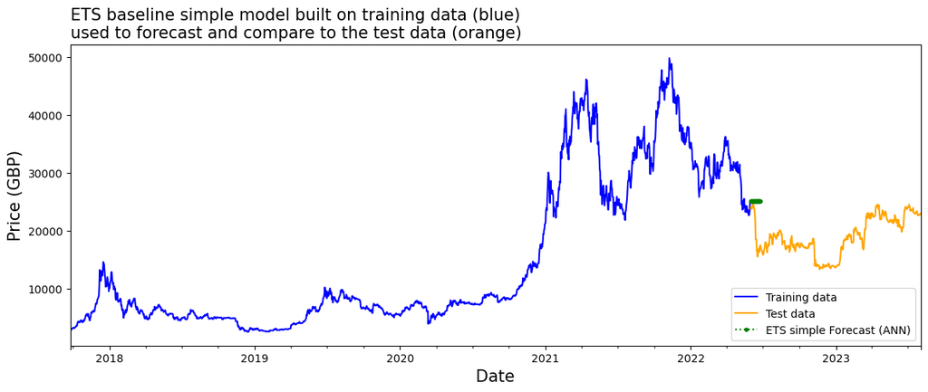

```python
# Plotting the training data, test data, and ETS simple forecast
ax = train_data['Close'].plot(color='blue')
test_data[['Close', 'ETS simple forecast (ANN)']].plot(ax=ax, style=['-', ':.', ':.'], color=['orange', 'green'], figsize=(14, 5))

# Adding legends and labels
plt.legend(labels=['Training data', 'Test data', 'ETS simple Forecast (ANN)'], loc=4)
plt.title("""ETS baseline simple model built on training data (blue)
used to forecast and compare to the test data (orange)""", fontsize=15, loc='left')
plt.xlabel('Date', fontsize=15)
plt.ylabel('Price (GBP)', fontsize=15)
plt.show()
```

- Blue Line (Training Data): This line represents the actual observed closing prices of Bitcoin from September 24, 2017, to May 31, 2022, which we used to train the ETS model.
- Orange Line (Test Data): This line shows the actual observed closing prices of Bitcoin from June 1, 2022 onward, which we are using to test the accuracy of our forecast.
- Green Dotted Line (ETS Simple Forecast): This line is the forecast generated by the ETS(ANN) model, which uses an Error, Trend, Seasonality (ETS) model with additive errors and no trend or seasonality components.

### Interpretation

The ETS simple forecast (ANN) model has predicted a constant value going forward. This is consistent with our earlier observation that the smoothing level was very close to 1, making this model similar to a naive forecast where the last observation is simply repeated.

As we can see, the forecast does not capture the dynamic changes in the Bitcoin price and stays constant. This illustrates the limitations of a simple model that does not account for the trend or seasonality in the data.

### 5 Selecting the model type

Of course, with the Bitcoin price dataset, we have insights that can guide a more refined forecast. From our Exploratory Data Analysis (EDA) and seasonal decomposition, we've identified the presence of a trend in the data.

We've explored these components and attempted to extract underlying patterns using techniques like moving averages and seasonal differencing. The ETS model allows us to consider these factors, breaking the data down into Level, Trend, and possibly Seasonality. The forecast for each period in the ETS model is based on a weighted average of preceding data points. The model will determine the best weights for us, which are represented as the `smoothing_level` (alpha), `smoothing_trend` (beta), and if seasonality is considered, `smoothing_seasonal` (gamma).

```
9711.95  (Root Mean Squared Error RMSE)
52.45  (Mean Absolute Percentage Error MAPE)
```

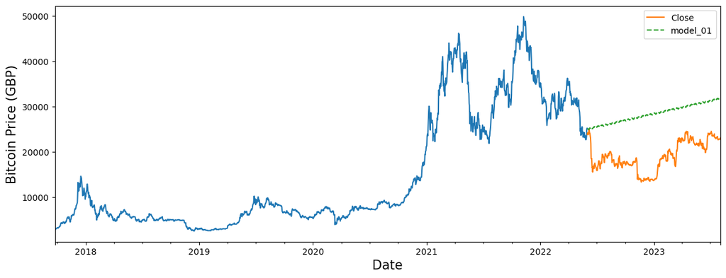

```python
# https://stats.stackexchange.com/a/294069

# Define the mean absolute percentage error function
def mean_absolute_percentage_error(y_true, y_pred):
    y_true, y_pred = np.array(y_true), np.array(y_pred)
    return np.mean(np.abs((y_true - y_pred) / y_true)) * 100

# 1: Build Model on training data
model_01 = sm.tsa.ETSModel(train_data['Close'].astype('float64'),
                           error='add',
                           trend='add',
                           damped_trend=False,
                           seasonal='add',
                           seasonal_periods=12,
                           freq='D').fit()

# 2: Use model to forecast across the same time span as test data
test_data['model_01'] = model_01.forecast(steps=len(test_data))

# 3: Plot forecast against real values in test data
ax = train_data['Close'].plot(figsize=(14, 5))
test_data[['Close', 'model_01']].plot(ax=ax, style=['-', '--'])
plt.xlabel('Date', fontsize=15)
plt.ylabel('Bitcoin Price (GBP)', fontsize=15);

# 4: Compare forecast to actual values statistically in test data
rmse = sm.tools.eval_measures.rmse(test_data['Close'], test_data['model_01']).round(2)
mape = mean_absolute_percentage_error(y_true=test_data['Close'], y_pred=test_data['model_01'])
print(rmse, ' (Root Mean Squared Error RMSE)')
print(round(mape, 2), ' (Mean Absolute Percentage Error MAPE)')
```

Two statistical measures are calculated for you that compare how close the forecast from the model is to the actual values in the test data. They are:

> [RMSE: Root Mean Squared Error](https://otexts.com/fpp3/accuracy.html#scale-dependent-errors)  
> [MAPE: Mean Absolute Percenrage Error](https://otexts.com/fpp3/accuracy.html#percentage-errors)

After each model you create for forecasting Bitcoin prices, you can utilize the two diagnostic plots below on the residuals (i.e. errors) to ensure:

The residuals (or errors) appear stationary. This means they look like white noise without any discernible pattern. If patterns are present, it suggests there's still some information in the residuals that could be captured by a different model type.

The Auto-Correlation Function (ACF) plot of the residuals (or errors) doesn't display significant correlations between each data point and its previous values (lagged by a certain number of periods). If significant correlations exist, it might indicate that the model hasn't fully captured the seasonality or patterns inherent in the Bitcoin price data. More about ACF can be found here.

https://www.statsmodels.org/stable/generated/statsmodels.graphics.tsaplots.plot_acf.html

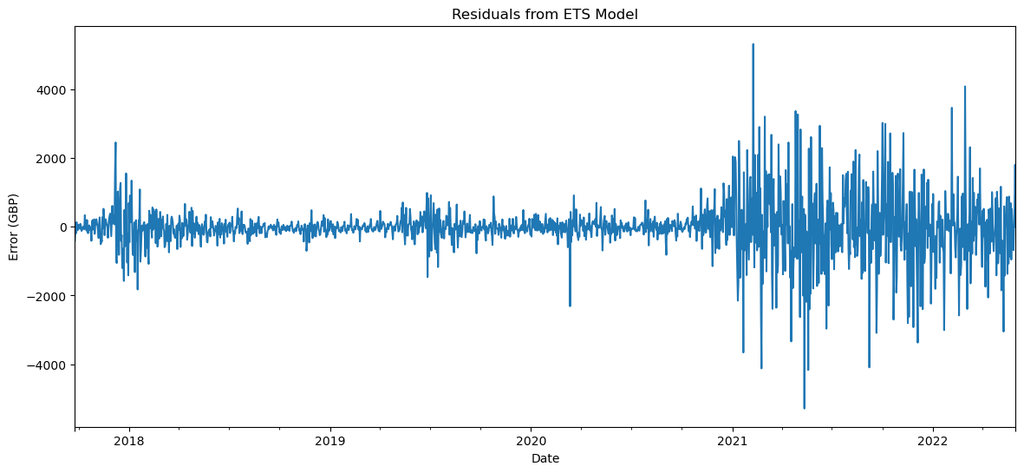

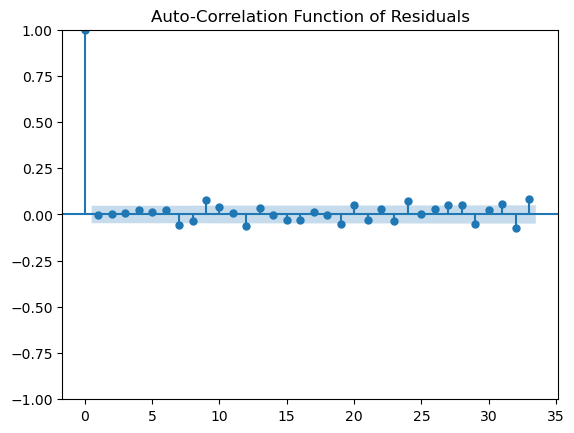

```python
import statsmodels.graphics.tsaplots as tsaplots

# Plotting residuals
plt.figure(figsize=(14, 6))
model_01.resid.plot()
plt.title('Residuals from ETS Model')
plt.ylabel('Error (GBP)')
plt.xlabel('Date')
plt.show()

# ACF plot of the residuals
tsaplots.plot_acf(model_01.resid, missing='drop', alpha=0.05, zero=True)
plt.title('Auto-Correlation Function of Residuals')
plt.show()
```

Residuals Plot: The residuals represent the difference between the actual data and the values predicted by our model. Ideally, for a good model, residuals should resemble white noise, meaning they should appear random and have no discernible patterns. In the plot, we observe that the residuals hover around zero, which is a positive sign. However, there are some noticeable fluctuations, indicating that there may be some patterns that our model didn't capture perfectly.

```python
model_01.summary()
```

ETS Results

| Dep. Variable: | Close | No. Observations: | 1711 |
| --- | --- | --- | --- |
| Model: | ETS(AAA) | Log Likelihood | -13751.301 |
| Date: | Sun, 06 Aug 2023 | AIC | 27538.602 |
| Time: | 17:20:15 | BIC | 27636.609 |
| Sample: | 09-24-2017 | HQIC | 27574.873 |
|  | - 05-31-2022 | Scale | 560237.392 |
| Covariance Type: | approx |  |  |

|  | coef | std err | z | P>\|z\| | [0.025 | 0.975] |
| --- | --- | --- | --- | --- | --- | --- |
| smoothing_level | 0.9787 | 0.024 | 40.295 | 0.000 | 0.931 | 1.026 |
| smoothing_trend | 0.0011 | nan | nan | nan | nan | nan |
| smoothing_seasonal | 0.0039 | nan | nan | nan | nan | nan |
| initial_level | 3067.6039 | 691.004 | 4.439 | 0.000 | 1713.260 | 4421.948 |
| initial_trend | 56.8162 | nan | nan | nan | nan | nan |
| initial_seasonal.0 | -110.6349 | 87.005 | -1.272 | 0.204 | -281.162 | 59.892 |
| initial_seasonal.1 | -141.5480 | 80.835 | -1.751 | 0.080 | -299.982 | 16.886 |
| initial_seasonal.2 | 66.4754 | 85.194 | 0.780 | 0.435 | -100.502 | 233.453 |
| initial_seasonal.3 | 128.0347 | 88.999 | 1.439 | 0.150 | -46.399 | 302.469 |
| initial_seasonal.4 | 209.9759 | 93.033 | 2.257 | 0.024 | 27.634 | 392.318 |
| initial_seasonal.5 | 275.8151 | 92.936 | 2.968 | 0.003 | 93.663 | 457.967 |
| initial_seasonal.6 | 211.1441 | 84.502 | 2.499 | 0.012 | 45.523 | 376.765 |
| initial_seasonal.7 | 168.5804 | 74.616 | 2.259 | 0.024 | 22.336 | 314.824 |
| initial_seasonal.8 | 237.5580 | 91.634 | 2.592 | 0.010 | 57.959 | 417.157 |
| initial_seasonal.9 | 194.0647 | 90.644 | 2.141 | 0.032 | 16.407 | 371.723 |
| initial_seasonal.10 | 75.9150 | 89.415 | 0.849 | 0.396 | -99.336 | 251.166 |
| initial_seasonal.11 | 0 | 87.927 | 0 | 1.000 | -172.333 | 172.333 |

| Ljung-Box (Q): | 59.59 | Jarque-Bera (JB): | 5706.50 |
| --- | --- | --- | --- |
| Prob(Q): | 0.00 | Prob(JB): | 0.00 |
| Heteroskedasticity (H): | 13.02 | Skew: | -0.13 |
| Prob(H) (two-sided): | 0.00 | Kurtosis: | 11.94 |

Warnings:  
[1] Covariance matrix calculated using numerical (complex-step) differentiation.  
[2] Covariance matrix is singular or near-singular, with condition number 2.91e+17. Standard errors may be unstable.

### 6. Make a forecast into the future

Once you have selected your final ETS model, refit the ETS model but this time using all of the data

```python
# Fit a final ETS model with the chosen parameters for Bitcoin data
final_model = sm.tsa.ETSModel(btc_data['Close'].astype('float64'),
                             error='add',           # UPDATE WITH YOUR FINAL SETTING
                             trend='add',           # UPDATE WITH YOUR FINAL SETTING
                             damped_trend=False,    # UPDATE WITH YOUR FINAL SETTING
                             seasonal='add',        # UPDATE WITH YOUR FINAL SETTING
                             seasonal_periods=12,   # This assumes a monthly seasonality.
                             freq='D').fit()        # 'D' denotes daily frequency
```

Previously I used .forecast() method on our model to forecast values over the same time period as the test data.

> This time, I will use the The ETS model method `get_prediction()` that will calculate a [mean prediction as well as prediction intervals](https://www.statsmodels.org/devel/examples/notebooks/generated/ets.html#Predictions).  
> For reference, this is how the intervals are [calculated](https://otexts.com/fpp3/ets-forecasting.html#prediction-intervals-3)

```python
# Get predictions for a specified range
pred = final_model.get_prediction(start='2021-01-01', end='2023-12-31')  # Adjust these dates as per your requirements

# Summarize the predictions into a dataframe with a 95% confidence interval (alpha=0.05)
df = pred.summary_frame(alpha=0.05)

df.tail()
```

|  | mean | pi_lower | pi_upper |
| --- | --- | --- | --- |
| 2023-12-27 | 24286.154791 | 6141.098837 | 42431.210744 |
| 2023-12-28 | 24403.021916 | 6185.408296 | 42620.635537 |
| 2023-12-29 | 24353.165294 | 6063.125442 | 42643.205146 |
| 2023-12-30 | 24294.835211 | 5932.498839 | 42657.171583 |
| 2023-12-31 | 24326.737632 | 5892.232758 | 42761.242506 |

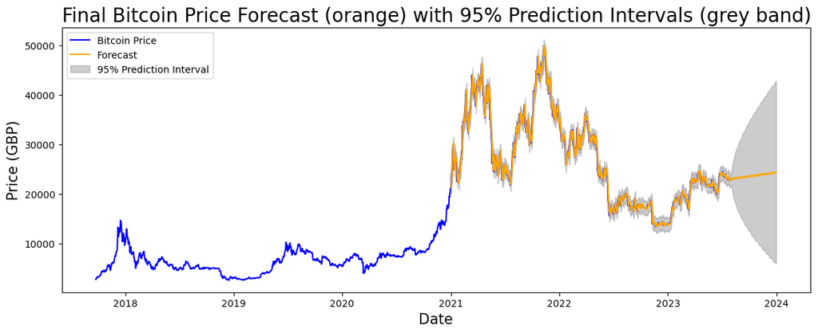

```python
# Splitting the dataset into train and test
train_data = btc_data[:'2020-12-31']
test_data = btc_data['2021-01-01':]

# Fitting the ETS model using all the data for the final forecast
final_model = sm.tsa.ETSModel(btc_data['Close'].astype('float64'),
                              error='add',
                              trend='add',
                              damped_trend=False,
                              seasonal='add',
                              seasonal_periods=12,
                              freq='D').fit()

# Get predictions for a specified range
pred = final_model.get_prediction(start='2021-01-01', end='2023-12-31')

# Summarize the predictions into a dataframe with a 95% confidence interval (alpha=0.05)
df = pred.summary_frame(alpha=0.05)

# Plotting the original data, forecast, and prediction intervals
fig, ax = plt.subplots(figsize=(14,5))

# Plotting the original Bitcoin data
ax.plot(btc_data['Close'], color='blue', label='Bitcoin Price')
# Plotting the forecasted mean
ax.plot(df['mean'], color='orange', label='Forecast')
# Plotting the 95% prediction intervals
ax.fill_between(df.index, y1=df['pi_lower'], y2=df['pi_upper'], color='grey', alpha=0.4, label='95% Prediction Interval')

# Setting title and labels
plt.title("Final Bitcoin Price Forecast (orange) with 95% Prediction Intervals (grey band)", fontsize=20, loc='left')
plt.xlabel('Date', fontsize=15)
plt.ylabel('Price (GBP)', fontsize=15)
plt.legend(loc='upper left')
plt.show()
```

- The blue line represents the actual historical Bitcoin prices over time.
- The orange line signifies our forecasted Bitcoin prices from the ETS model. This forecast extends from the beginning of 2021 to the end of 2023.
- The grey band surrounding the forecast line represents the 95% prediction interval. This interval provides a measure of the uncertainty associated with our forecast. It indicates the range within which we expect the actual Bitcoin prices to fall 95% of the time, given our forecasting mode

## Summary

#### Back to Table of Contents

The project aimed to predict the future prices of Bitcoin using historical daily closing prices. I employed the Exponential Smoothing State Space Model (ETS), a time series forecasting approach that accounts for various patterns like trend and seasonality.

**Constraints:**

1. **Historical Data Limitation:** Like all time series forecasts, the predictions are entirely based on historical data. If new, unforeseen factors (e.g., regulatory changes, significant global events) influence Bitcoin prices, the forecast may not capture such deviations.
2. **Model Limitation:** The ETS model, while robust, is just one of many potential forecasting methods. Different models may yield slightly different forecasts.
3. **Stationarity Assumption:** For most time series models, including ETS, the assumption is that the underlying processes generating the series are stable over time. If this isn't the case, it can lead to inaccurate predictions.

**Recommendations:**

1. **Model Diversification:** Consider employing other forecasting methods like ARIMA, Prophet, or LSTM neural networks. This will allow for ensemble methods where multiple forecasts are combined for potentially improved accuracy.
2. **Regular Updates:** Regularly update the model with new data. As more data becomes available, the forecast can be refined and adjusted.
3. **External Factors:** Integrate external factors or indicators that might influence Bitcoin prices, like global financial indices, other cryptocurrency prices, or regulatory news.

**Next Steps:**

1. **Parameter Optimization:** Use techniques like grid search to fine-tune the model parameters further.
2. **Model Evaluation:** Implement a rolling forecast origin method to evaluate the model's performance over multiple forecast horizons.
3. **Feature Engineering:** Incorporate technical indicators (e.g., moving averages, RSI) and other relevant datasets to improve the model.
4. **Deep Learning:** Explore deep learning models like Long Short-Term Memory (LSTM) networks, which have shown promise in time series forecasting.

**Final Thoughts:**

While the forecast provides valuable insights into potential future Bitcoin prices, it's crucial to approach it and any other financial forecast with caution. No model can predict the future with absolute certainty. It's always recommended to combine quantitative forecasts like this with qualitative analysis and expert judgment before making investment decisions.